# SDS291 - Final Project

Lauren Forando, Elle Jo Whalen, Jemimah Charles

12/14/2019

#### Estimating Neck Circumference Based on an Individual’s Height, Weight, Age, Bicep Size, and Wrist Size.

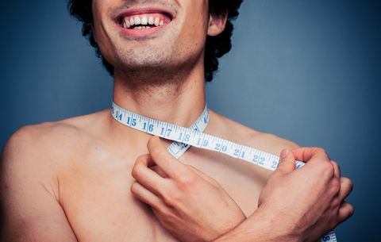

## Abstract:

The purpose of this project was to estimate a male individual’s neck circumference based on their age, weight, wrist size, bicep size, and height. The data set “bodyfat” was used, and includes various body circumference measurements for 252 men between the ages of 22 and 81. We were interested in analyzing whether or not there is a relationship between anticipated neck size and the age, weight, wrist circumference, bicep circumference, and height of an individual. Based on our statistical analyses, it has been found that weight, wrist circumference, and bicep circumference are good predictors of one’s neck circumference; whereas age and height are not as good of predictors for neck circumference. Our regression model having weight, wrist circumference, and bicep circumference as the predictor variables had the smaller of the two p-values was compared to the regression model including age but not height (p-value = 0.03058), and when compared to the full model (p-value = 0.09383). Overall, the higher a man’s weight, bicep and wrist circumference are, the larger his predicted neck size will be.

## Introduction:

Knowing your neck circumference is a common measurement that men often need to know in order to buy clothing such as a button down shirt or neck ties. It has also been found that there is a connection between neck size, sleep apnea, and snoring. The larger one’s neck is, the more likely they will have health complications (such as breathing when sleeping). Therefore, knowing one’s neck size is not only important for fashion reasons but also health reasons.

## Data:

The original data set includes estimates of the percentage of body fat determined by underwater weighing and various body circumference measurements for 252 men between the ages of 22 and 81. While the initial purpose of the data set was to determine body fat percentage of men based on a multitude of predictor variables, in our case we are interested in exploring whether or not there is a linear relationship between an individuals’ neck circumference and age, weight, wrist circumference, bicep circumference and height; and if we can appropriately estimate an individuals’ neck circumference knowing their age, weight, wrist circumference, bicep circumference and height.

The original data set can be found here: http://lib.stat.cmu.edu/datasets/bodyfat.

Our population is 252 men between the ages of 22 and 81. The following variables were collected for each of the men: Density determined from underwater weighing, Percent body fat from Siri’s (1956) equation, Age (years), Weight (lbs), Height (inches), Neck circumference (cm), Chest circumference (cm), Abdomen 2 circumference (cm), Hip circumference (cm), Thigh circumference (cm), Knee circumference (cm), Ankle circumference (cm), Biceps (extended) circumference (cm), Forearm circumference (cm), Wrist circumference (cm). Each column of the data set (from left to right) corresponds to each variable (first to last). With this data we will find the estimate of a male individual’s neck circumference based on their age, weight, wrist circumference, bicep circumference and height.

## Results:

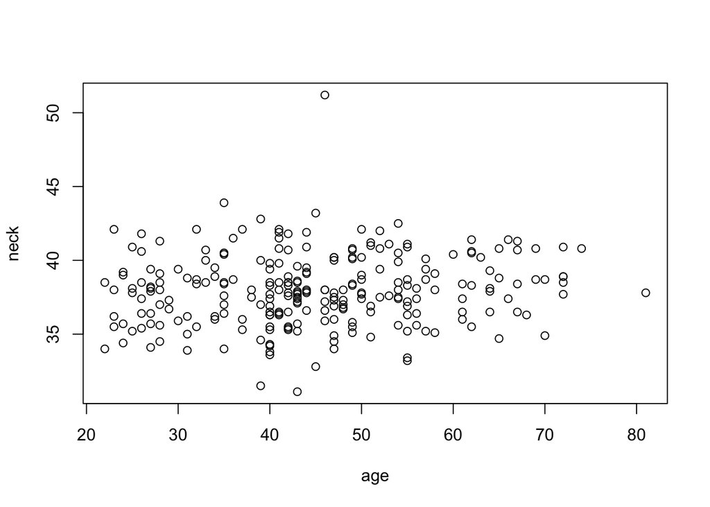

```r
plot(neck ~ age, data = neck_size)
```

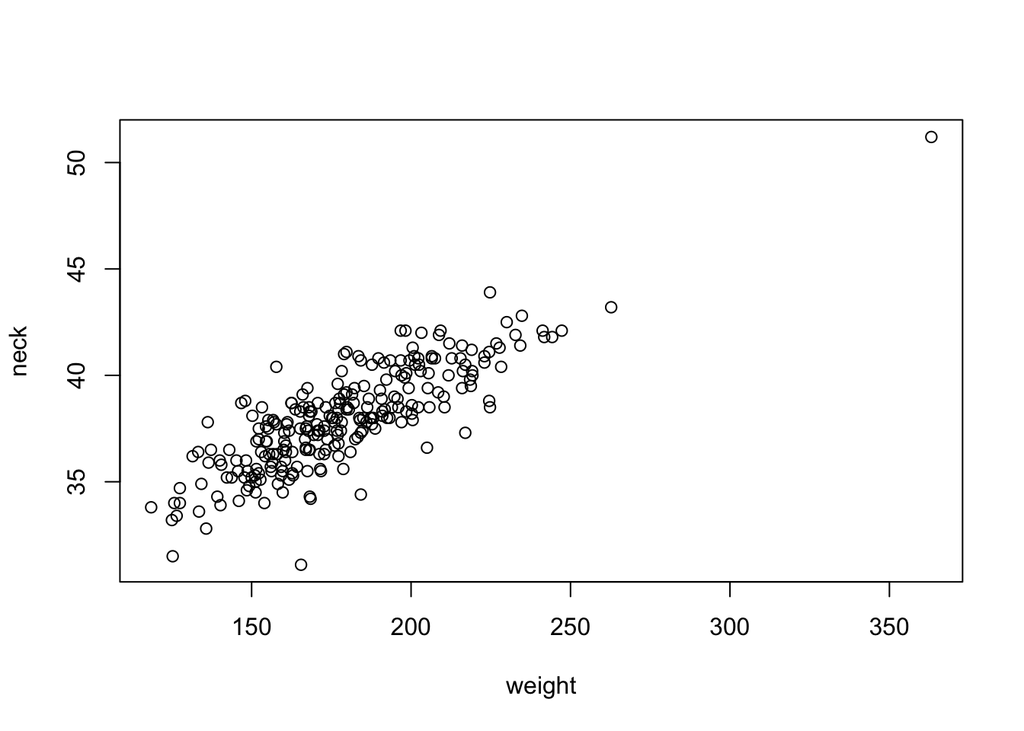

```r
plot(neck ~ weight, data = neck_size)
```

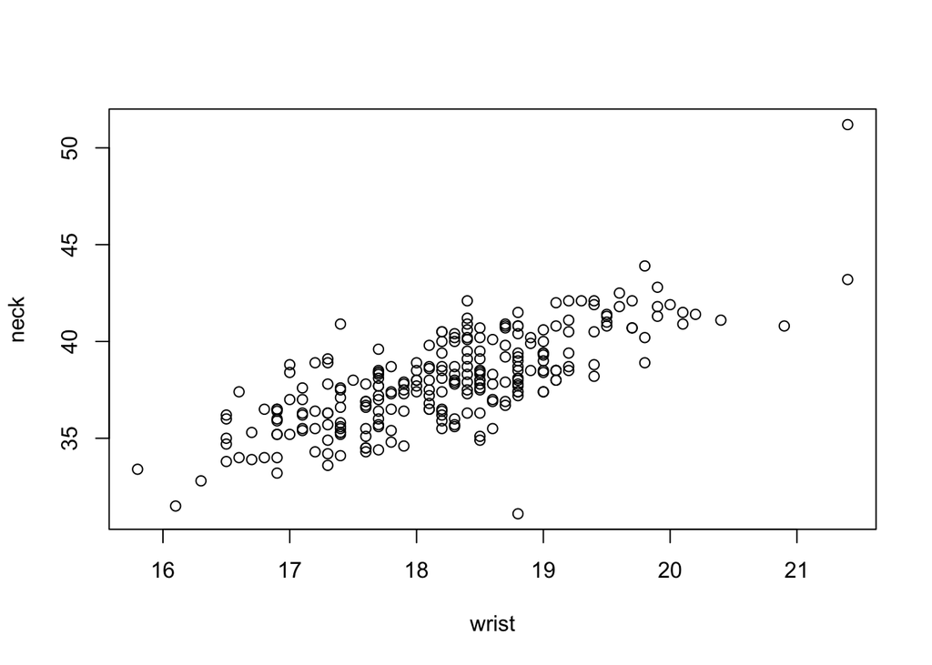

```r
plot(neck ~ wrist, data = neck_size)
```

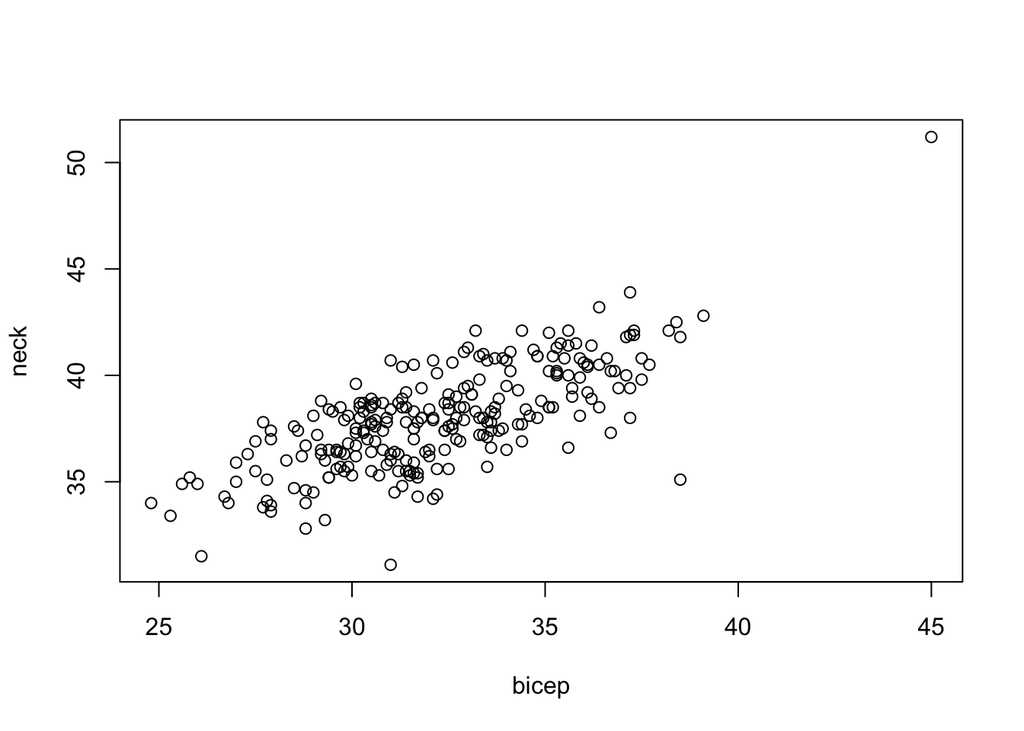

```r
plot(neck ~ bicep, data = neck_size)
```

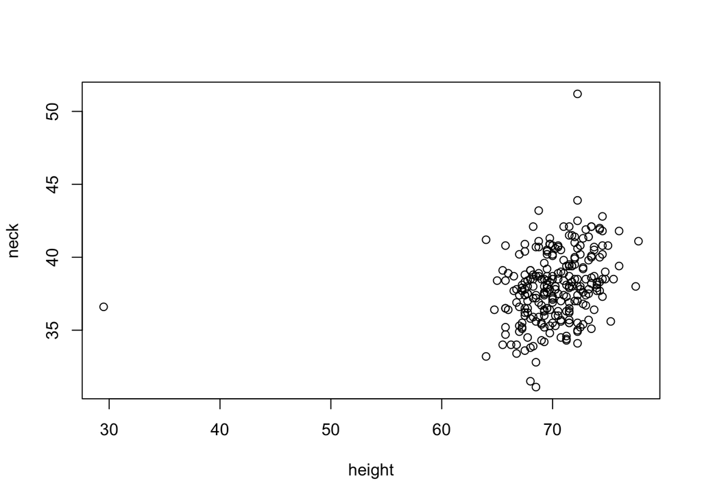

```r
plot(neck ~ height, data = neck_size)
```

If we look at the individual scatter plots for each of our predictor variables, we see that weight, wrist size, and bicep size all have fairly strong positive linear correlations with neck size. However, both age and height show almost no correlation with neck size.

```r
#Multiple Regression Model With Our 5 Predictor Variables
neck_lm <- lm(neck ~ age + weight + wrist + bicep + height, data = neck_size)
summary(neck_lm)
```

```
##
## Call:
## lm(formula = neck ~ age + weight + wrist + bicep + height, data = neck_size)
##
## Residuals:
##     Min      1Q  Median      3Q     Max
## -6.4970 -0.7821 -0.0143  0.8372  3.5173
##
## Coefficients:
##              Estimate Std. Error t value Pr(>|t|)
## (Intercept) 14.143096   2.251838   6.281 1.52e-09 ***
## age          0.013922   0.006835   2.037   0.0427 *
## weight       0.043700   0.005163   8.464 2.35e-15 ***
## wrist        0.645551   0.135174   4.776 3.08e-06 ***
## bicep        0.125852   0.044108   2.853   0.0047 **
## height      -0.006057   0.023614  -0.256   0.7978
## ---
## Signif. codes:  0 '***' 0.001 '**' 0.01 '*' 0.05 '.' 0.1 ' ' 1
##
## Residual standard error: 1.243 on 246 degrees of freedom
## Multiple R-squared:  0.7438, Adjusted R-squared:  0.7386
## F-statistic: 142.8 on 5 and 246 DF,  p-value: < 2.2e-16
```

```r
#Multiple Regression Model w/o Height
no_height_lm <- lm(neck ~ age + weight + wrist + bicep, data = neck_size)
summary(no_height_lm)
```

```
##
## Call:
## lm(formula = neck ~ age + weight + wrist + bicep, data = neck_size)
##
## Residuals:
##     Min      1Q  Median      3Q     Max
## -6.4818 -0.7739 -0.0159  0.8339  3.5288
##
## Coefficients:
##              Estimate Std. Error t value Pr(>|t|)
## (Intercept) 13.832448   1.894772   7.300 3.92e-12 ***
## age          0.014362   0.006603   2.175  0.03058 *
## weight       0.043554   0.005122   8.504 1.77e-15 ***
## wrist        0.637353   0.131092   4.862 2.07e-06 ***
## bicep        0.127144   0.043736   2.907  0.00398 **
## ---
## Signif. codes:  0 '***' 0.001 '**' 0.01 '*' 0.05 '.' 0.1 ' ' 1
##
## Residual standard error: 1.241 on 247 degrees of freedom
## Multiple R-squared:  0.7437, Adjusted R-squared:  0.7396
## F-statistic: 179.2 on 4 and 247 DF,  p-value: < 2.2e-16
```

```r
#Multiple Regression Model w/o Height and Age
no_age_lm <- lm(neck ~ weight + wrist + bicep, data = neck_size)
summary(no_age_lm)
```

```
##
## Call:
## lm(formula = neck ~ weight + wrist + bicep, data = neck_size)
##
## Residuals:
##     Min      1Q  Median      3Q     Max
## -6.5956 -0.8024  0.0027  0.8637  3.3711
##
## Coefficients:
##             Estimate Std. Error t value Pr(>|t|)
## (Intercept) 13.30682    1.89338   7.028 2.02e-11 ***
## weight       0.04201    0.00511   8.221 1.14e-14 ***
## wrist        0.73280    0.12445   5.888 1.26e-08 ***
## bicep        0.11804    0.04386   2.691   0.0076 **
## ---
## Signif. codes:  0 '***' 0.001 '**' 0.01 '*' 0.05 '.' 0.1 ' ' 1
##
## Residual standard error: 1.25 on 248 degrees of freedom
## Multiple R-squared:  0.7388, Adjusted R-squared:  0.7356
## F-statistic: 233.8 on 3 and 248 DF,  p-value: < 2.2e-16
```

First, we wanted to analyze the relationship between anticipated neck size and age, weight, wrist circumference, bicep circumference, and height. Because we are looking at multiple predictor variables, we will be running a Multiple Linear Regression (MLR) model.

After analyzing our first model, we wanted to know if we could find a simpler model that can tell us roughly the same about estimating neck size. This lead us to taking out height for Model 2. We then went even further and decided to take out age for Model 3. More is explained about this when analyzing the ANOVA tables.

Including height only increases our $R^2$ value by 0.0001. By removing height, our adjusted $R^2$ increases from 0.7386 to 0.7396. So, the model without height is a better predictor of neck size than the model including height. Looking at the p-values for the coefficients in our first model, we see that the p-value for height is 0.7978 making this variable not statistically significant to our regression model. Therefore, we removed it in our second model. Then, turning to our coefficient p-values in our second regression model, we see that age has the highest p-value at 0.03058, although being low enough to be statistically significant, it was still very high compared to the other p-values. We removed this because looking back at the individual scatter plots we see that the scatter plot between neck circumference and age had little to no correlation.

Looking at Model 3, which does not include height or age, we have a slightly lower $R^2$ and adjusted $R^2$ value compared to Model 2, but now our coefficients are all statistically significant at a more extreme confidence level.

Looking at the coefficients for Model 3, we can interpret the following:

- The intercept of “neck” is understood as for someone who weighs zero pounds and has both a wrist and bicep circumference of zero centimeters, will have a neck circumference of 13.31 cm.
- The coefficient of “weight” is understood as for every increase of one pound in someone’s weight, there is a 0.042 cm increase in the measurement of someone’s neck, holding all other variables constant.
- The coefficient of “wrist” is understood as for every increase in the measurement of someone’s wrist circumference by one centimeter, there is a 0.73 cm increase in the measurement of someone’s neck, holding all other variables constant.
- The coefficient of “bicep” is understood as for every increase in the measurement of someone’s bicep circumference by one centimeter, there is a 0.118 cm increase in the measurement of someone’s neck, holding all other variables constant.

```r
#ANOVA of our three possible models to determine which model is the best.

#ANOVA of Model 2 and Model 1
anova(no_height_lm, neck_lm)
```

```
## Analysis of Variance Table
##
## Model 1: neck ~ age + weight + wrist + bicep
## Model 2: neck ~ age + weight + wrist + bicep + height
##   Res.Df    RSS Df Sum of Sq      F Pr(>F)
## 1    247 380.13
## 2    246 380.03  1   0.10162 0.0658 0.7978
```

```r
#ANOVA of Model 3 and Model 1
anova(no_age_lm, neck_lm)
```

```
## Analysis of Variance Table
##
## Model 1: neck ~ weight + wrist + bicep
## Model 2: neck ~ age + weight + wrist + bicep + height
##   Res.Df    RSS Df Sum of Sq      F  Pr(>F)
## 1    248 387.41
## 2    246 380.03  2    7.3819 2.3892 0.09383 .
## ---
## Signif. codes:  0 '***' 0.001 '**' 0.01 '*' 0.05 '.' 0.1 ' ' 1
```

```r
#ANOVA of Model 3 and Model 2
anova(no_age_lm, no_height_lm)
```

```
## Analysis of Variance Table
##
## Model 1: neck ~ weight + wrist + bicep
## Model 2: neck ~ age + weight + wrist + bicep
##   Res.Df    RSS Df Sum of Sq      F  Pr(>F)
## 1    248 387.41
## 2    247 380.13  1    7.2803 4.7306 0.03058 *
## ---
## Signif. codes:  0 '***' 0.001 '**' 0.01 '*' 0.05 '.' 0.1 ' ' 1
```

**Confidence Intervals**

```r
#Finding the 95% confidence Intervals for our third model
confint(no_age_lm)
```

```
##                  2.5 %      97.5 %
## (Intercept) 9.57766561 17.03596952
## weight      0.03194604  0.05207665
## wrist       0.48767606  0.97792142
## bicep       0.03165438  0.20443122
```

We are 95% confident that the true effect of weight on neck circumference, controlling for wrist and bicep circumference, is 0.03194604 and 0.05207665 cm. We are 95% confident that the true effect of wrist circumference on neck circumference, controlling for weight and bicep circumference, is 0.48767606 and 0.97792142 cm. We are 95% confident that the true effect of bicep circumference on neck circumference, controlling for weight and wrist circumference, is 0.03165438 and 0.20443122 cm.

**VIF**

```r
#Variance Inflation Factor - used to check Collinearity
vif(no_age_lm)
```

```
##   weight    wrist    bicep
## 3.624413 2.169122 2.821634
```

Since all three coefficients analyzed are less than 5, there is no collinearity between these variables.

**Residual Plots**

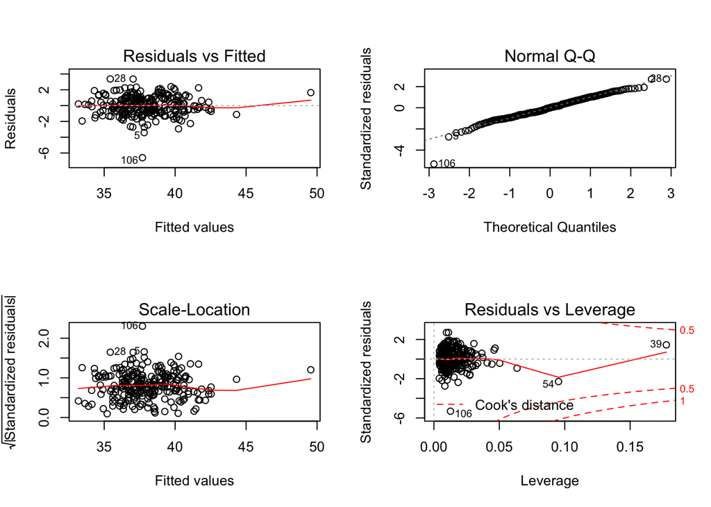

```r
#Plot residuals
par(mfrow=c(2,2))
plot(no_age_lm)
```

**Identifying Unusual Points**

```r
#Outliers, Leverage, and Influence
##Outliers: Points that do not fit the regression line well, far away vertically from other points.
##Leverage: How far away a point is horizontally from the center of the data.
##Influence: How much a point draws the slope of the regression toward that point

#Identifying Unusual Points in Regression
neck_diag <- ls.diag(no_age_lm)

hi_funusual = 8/282
hi_vunusual = 10/282

Unusual_Neck <- neck_size %>%
mutate(h_i = neck_diag$hat,
       resid = no_age_lm$resid,
       stnd_res = neck_diag$std.res,
       stud_res = neck_diag$stud.res,
       fitted = no_age_lm$fitted,
       cooks = neck_diag$cooks) %>%
  filter(stnd_res > 2|stnd_res < -2| stud_res > 2|stud_res < -2| cooks >= 0.5| h_i >= hi_funusual)

Unusual_Neck
```

```
## # A tibble: 26 x 12
##      age weight wrist bicep height  neck     h_i  resid stnd_res stud_res fitted
##    <dbl>  <dbl> <dbl> <dbl>  <dbl> <dbl>   <dbl>  <dbl>    <dbl>    <dbl>  <dbl>
##  1    24   184.  17.7  32.2   71.2  34.4 0.00838 -3.42    -2.75    -2.78    37.8
##  2    34   196.  17.3  36.2   71    38.9 0.0333   0.419    0.341    0.340   38.5
##  3    28   184.  18.5  37.2   67.8  38   0.0290  -0.974   -0.791   -0.791   39.0
##  4    31   148   17    29.2   67.5  38.8 0.0111   3.37     2.71     2.75    35.4
##  5    46   363.  21.4  45     72.2  51.2 0.178    1.64     1.45     1.45    49.6
##  6    45   263.  21.4  36.4   68.8  43.2 0.0635  -1.12    -0.929   -0.929   44.3
##  7    48   217   18.4  36.7   70    37.3 0.0185  -2.94    -2.37    -2.40    40.2
##  8    47   158.  17.3  26     72.2  34.9 0.0320  -0.802   -0.652   -0.651   35.7
##  9    49   153.  18.5  38.5   73.5  35.1 0.0952  -2.73    -2.29    -2.31    37.8
## 10    42   136.  18.5  27.7   67.5  37.8 0.0306   1.94     1.58     1.58    35.9
## # … with 16 more rows, and 1 more variable: cooks <dbl>
```

```r
V_Unusual_Neck <- neck_size %>%
mutate(h_i = neck_diag$hat,
       resid = no_age_lm$resid,
       stnd_res = neck_diag$std.res,
       stud_res = neck_diag$stud.res,
       fitted = no_age_lm$fitted,
       cooks = neck_diag$cooks) %>%
  filter(stnd_res > 3|stnd_res < -3| stud_res > 3|stud_res < -3| cooks >= 1| h_i >= hi_vunusual)

V_Unusual_Neck
```

```
## # A tibble: 11 x 12
##      age weight wrist bicep height  neck    h_i  resid stnd_res stud_res fitted
##    <dbl>  <dbl> <dbl> <dbl>  <dbl> <dbl>  <dbl>  <dbl>    <dbl>    <dbl>  <dbl>
##  1    46   363.  21.4  45     72.2  51.2 0.178   1.64     1.45     1.45    49.6
##  2    45   263.  21.4  36.4   68.8  43.2 0.0635 -1.12    -0.929   -0.929   44.3
##  3    49   153.  18.5  38.5   73.5  35.1 0.0952 -2.73    -2.29    -2.31    37.8
##  4    53   224.  20.4  32.9   77.8  41.1 0.0407 -0.471   -0.385   -0.384   41.6
##  5    43   166.  18.8  31     68.5  31.1 0.0127 -6.60    -5.31    -5.63    37.7
##  6    47   178.  19.8  35.3   70    40.2 0.0366  0.728    0.594    0.593   39.5
##  7    37   241.  18.4  34.4   71.5  42.1 0.0460  1.11     0.912    0.912   41.0
##  8    44   223   17.4  34.8   69.8  40.9 0.0467  1.37     1.12     1.12    39.5
##  9    55   126.  15.8  25.3   66.8  33.4 0.0373  0.214    0.175    0.174   33.2
## 10    70   134.  18.5  25.6   67    34.9 0.0444 -0.626   -0.512   -0.511   35.5
## 11    74   208.  20.9  33.7   70    40.8 0.0503 -0.518   -0.425   -0.424   41.3
## # … with 1 more variable: cooks <dbl>
```

There are 26 possible men that can be classified as “unusual”. The 26 men are given in the first table above, including their age, weight, wrist circumference, bicep circumference, height, and neck circumference, as well as the diagnostic statistics that consider them “fairly unusual.” Out of those 26 men, 11 of them can be considered “very unusual”, which can be seen in the second table above.

## Conclusion:

In the future, we would like to be able to collect data that has classified the participants by race, the interactive term of significant weight loss and age. As this data was collected in the pool, gravity did not play a factor in regards to measurement. As muscle is lost as you get older, it would be interesting to see how this affect’s someone’s neck size. Another interesting effect on one’s neck size could be the interactive term of someone losing a significant amount of weight and skin retention. Someone may have weighed more in the past and now just has excess skin.